# Homework 4

Author

Kyle Wakerley

```r
library(RSQLite)
library(DBI)
library(microbenchmark)
library(ggplot2)
library(knitr)
library(dplyr)
con <- dbConnect(SQLite(), ":memory:")
```

## HPC

### Question 1

```r
# running cumulative sum by row
fun2 <- function(mat) {
  n <- nrow(mat)
  k <- ncol(mat)
  ans <- mat
  for (i in 1:n) {
    for (j in 2:k) {
      ans[i,j] <- mat[i, j] + ans[i, j - 1]
    }
  }
  ans
}

fun2alt <- function(mat) {
  t(apply(mat, 1, cumsum))
}
```

```r
# Use the functions with this data
set.seed(2315)
dat <- matrix(rnorm(200 * 100), nrow = 200)

microbenchmark(fun2(dat), fun2alt(dat))
```

```
Unit: microseconds
         expr      min       lq      mean   median        uq      max neval
    fun2(dat) 1426.901 1478.901 1691.8251 1535.650 1609.0505 6218.301   100
 fun2alt(dat)  419.101  486.950  845.9589  659.051  761.3515 7421.201   100
```

I used the cumsum function since it is highly optimized, along with t(apply) (even though that can be slow). Looking at the microbenchmark results we see that the alternate function is faster on average compared to the original slower function which used for loops.

### Question 2

```r
set.seed(1234)
v = sample(0:9, size = 100000, replace = TRUE)

fun3 <- function(x) {
  out <- numeric(length(x))
  cumsum_x <- 0
  for (i in seq_along(x)) {
    if (x[i] == 0) {
      cumsum_x <- 0
    } else {
      cumsum_x <- cumsum_x + x[i]
    }
    out[i] <- cumsum_x
  }
  out
}


fun3alt = function(v) {
  cs = cumsum(v) # Running total
  last_zero = cummax((v == 0) * seq_along(v)) #index of the most recent 0 in the vector
  baseline = numeric(length(v)) #vector of 0s
  index = last_zero > 0 # index of everything thats not zero
  baseline[index] = cs[last_zero[index]]
  cs - baseline
}

microbenchmark(fun3(v), fun3alt(v), times = 1000)
```

```
Unit: milliseconds
       expr      min        lq      mean    median        uq      max neval
    fun3(v) 5.627001 18.414651 19.772060 21.177400 23.206700  38.1079  1000
 fun3alt(v) 1.531201  5.612302  7.117153  6.358951  7.321701 172.1734  1000
```

### Question 3

```r
library(parallel)

sim_pi <- function(n = 1000, i = NULL) {
  p <- matrix(runif(n*2), ncol = 2)
  mean(rowSums(p^2) < 1) * 4
}

# Here is an example of the run
set.seed(156)
sim_pi(1000) # 3.132
```

```
[1] 3.132
```

```r
# This runs the simulation a 4,000 times, each with 10,000 points
set.seed(1231)
system.time({
  ans1 <- unlist(lapply(1:4000, sim_pi, n = 10000))
  print(mean(ans1))
})
```

```
[1] 3.14124
```

```
   user  system elapsed
   3.82    0.37    4.43
```

```r
time1 = replicate(30,system.time({
 ans1 <- unlist(lapply(1:4000, sim_pi, n = 10000))
}))
```

```r
cl <- makeCluster(3L)
clusterExport(cl, varlist = c("sim_pi"))
clusterSetRNGStream(cl, 1231)

system.time({
  ans2 <- unlist(parLapply(cl, 1:4000, sim_pi, n = 10000))
  print(mean(ans2))
})
```

```
[1] 3.14125
```

```
   user  system elapsed
   0.02    0.00    0.89
```

```r
time2 = replicate(30, system.time({
  ans2 <- unlist(parLapply(cl, 1:4000, sim_pi, n = 10000))
}))

stopCluster(cl)
```

I used parLapply to run the same process as above, just on multiple cores instead of 1.

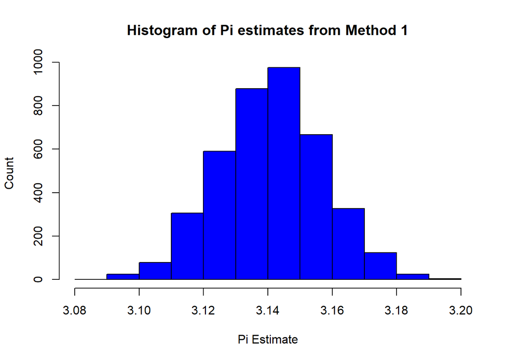

```r
hist(ans1,
     main = "Histogram of Pi estimates from Method 1",
     xlab = "Pi Estimate",
     ylab = "Count",
     col = "blue")
```

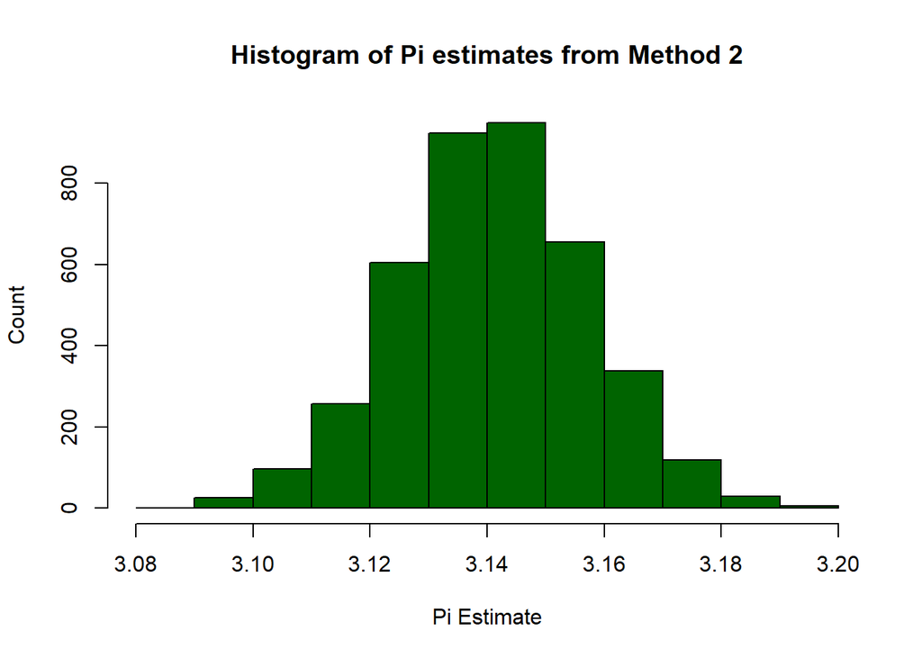

```r
hist(ans2,
     main = "Histogram of Pi estimates from Method 2",
     xlab = "Pi Estimate",
     ylab = "Count",
     col = "darkgreen")
```

#### Checking Time of Each Method

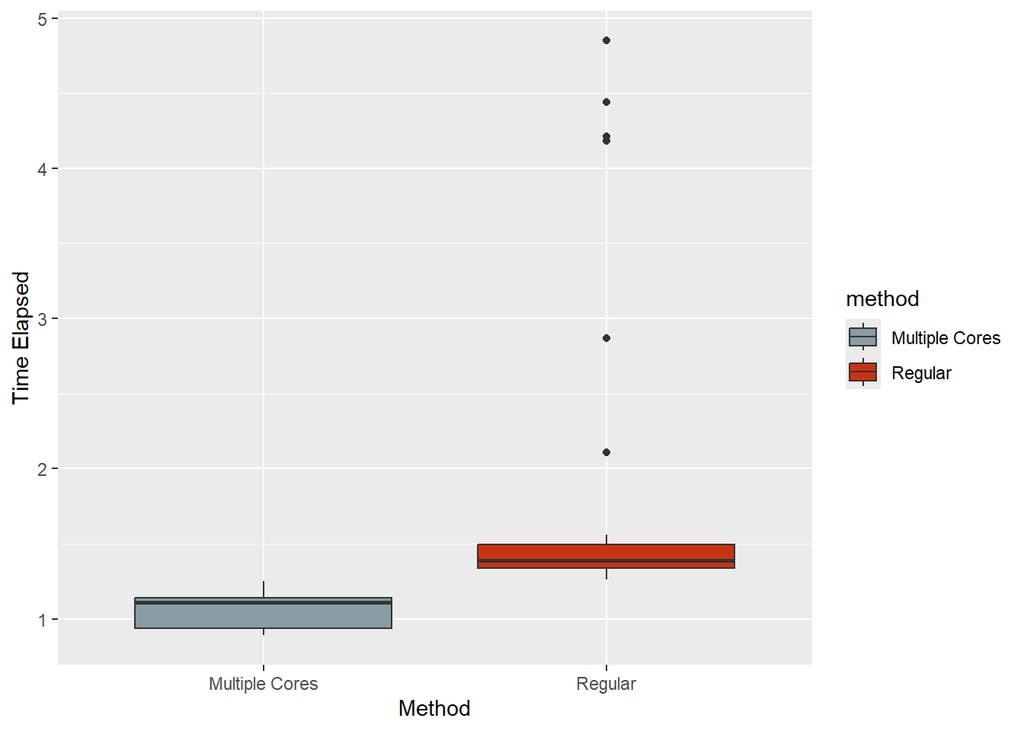

```r
library(tidyr)
library("wesanderson")

time1small = time1[3,] %>% as.data.frame()
names(time1small) = "Regular"
time2small = time2[3,] %>% as.data.frame()
names(time2small) = "Multiple Cores"

times = cbind(time1small, time2small) %>%
  pivot_longer(cols = everything(),
               names_to = "method",
               values_to = "time")

ggplot(times) +
  geom_boxplot(aes(x = method, y = time, fill = method)) +
  scale_fill_manual(values = wes_palette("Royal1")) +
  labs(x = "Method", y = "Time Elapsed")
```

The paralellized version runs consitently faster than the sequential version.

## SQL

```r
surveys = read.csv("C:/Users/kylew/Downloads/1314459/surveys.csv")
species = read.csv("C:/Users/kylew/Downloads/1314459/species.csv")
plots = read.csv("C:/Users/kylew/Downloads/1314459/plots.csv")

dbWriteTable(con, "surveys", surveys)
dbWriteTable(con, "species", species)
dbWriteTable(con, "plots", plots)
```

Here I read in the data

### Question 4

```sql
PRAGMA table_info(surveys)
```

9 records

| cid | name | type | notnull | dflt_value | pk |
| --- | --- | --- | --- | --- | --- |
| 0 | record_id | INTEGER | 0 | NA | 0 |
| 1 | month | INTEGER | 0 | NA | 0 |
| 2 | day | INTEGER | 0 | NA | 0 |
| 3 | year | INTEGER | 0 | NA | 0 |
| 4 | plot_id | INTEGER | 0 | NA | 0 |
| 5 | species_id | TEXT | 0 | NA | 0 |
| 6 | sex | TEXT | 0 | NA | 0 |
| 7 | hindfoot_length | INTEGER | 0 | NA | 0 |
| 8 | weight | INTEGER | 0 | NA | 0 |

The query above helps us get a look at the data. Surveys has nine columns and many rows, with all but species_id and sex being integers.

```sql
SELECT month, day, year, species_id, ROUND(weight, 2)
FROM surveys
WHERE year = 1999
ORDER BY species_id
```

Displaying records 1 - 10

| month | day | year | species_id | ROUND(weight, 2) |
| --- | --- | --- | --- | --- |
| 1 | 17 | 1999 |  | NA |
| 2 | 21 | 1999 |  | NA |
| 2 | 21 | 1999 |  | NA |
| 2 | 21 | 1999 |  | NA |
| 3 | 15 | 1999 |  | NA |
| 3 | 15 | 1999 |  | NA |
| 3 | 15 | 1999 |  | NA |
| 4 | 17 | 1999 |  | NA |
| 4 | 18 | 1999 |  | NA |
| 4 | 18 | 1999 |  | NA |

The query does use the round function, however all of the weight values are integers. This effectively does nothing. The species ID column looks empty because we have some species with no id value.

### Question 5

```sql
SELECT species_id, SUM(weight), MAX(weight), AVG(weight), MIN(weight)
FROM surveys
GROUP BY species_id;
```

Displaying records 1 - 10

| species_id | SUM(weight) | MAX(weight) | AVG(weight) | MIN(weight) |
| --- | --- | --- | --- | --- |
|  | NA | NA | NA | NA |
| AB | NA | NA | NA | NA |
| AH | NA | NA | NA | NA |
| AS | NA | NA | NA | NA |
| BA | 387 | 18 | 8.6 | 6 |
| CB | NA | NA | NA | NA |
| CM | NA | NA | NA | NA |
| CQ | NA | NA | NA | NA |
| CS | NA | NA | NA | NA |
| CT | NA | NA | NA | NA |

For the 49 unique species ids, the total weights, max weight, mean weight, and min weight are shows. A lot of NA values.

```sql
SELECT species_id, SUM(weight), MAX(weight), AVG(weight), MIN(weight)
FROM surveys
WHERE weight >= 5 AND weight <= 10
GROUP BY species_id
```

Displaying records 1 - 10

| species_id | SUM(weight) | MAX(weight) | AVG(weight) | MIN(weight) |
| --- | --- | --- | --- | --- |
| BA | 322 | 10 | 8.050000 | 6 |
| DM | 10 | 10 | 10.000000 | 10 |
| OL | 10 | 10 | 10.000000 | 10 |
| OT | 82 | 10 | 9.111111 | 5 |
| PE | 46 | 10 | 9.200000 | 8 |
| PF | 11512 | 10 | 7.757412 | 5 |
| PL | 28 | 10 | 9.333333 | 8 |
| PM | 192 | 10 | 9.142857 | 7 |
| PP | 668 | 10 | 9.277778 | 5 |
| RF | 49 | 10 | 9.800000 | 9 |

I used the where function to help remove weights outside the specified range.

### Question 6

```r
result = dbGetQuery(con,
                    "SELECT species_id,
                    year,
                    COUNT(*),
                    AVG(weight) FROM surveys GROUP BY year,
                    species_id")
head(result)
```

```
  species_id year COUNT(*) AVG(weight)
1            1977       16          NA
2         DM 1977      264    41.14130
3         DO 1977       12    42.66667
4         DS 1977       98   121.43750
5         NL 1977       31          NA
6         OL 1977       10    21.66667
```

For each different species ID and year I counted the number of observations and the average weight. I stored this result as an R object

### Question 7

```sql
SELECT COUNT(*) AS count, taxa
FROM species
GROUP BY taxa
HAVING COUNT(*) > 10
```

2 records

| count | taxa |
| --- | --- |
| 13 | Bird |
| 31 | Rodent |

Birds have 13 species in their taxa and Rodents have 31.

### Question 8

```sql
SELECT genus, plot_id, COUNT(species)
FROM species
INNER JOIN surveys ON species.species_id = surveys.species_id
GROUP BY genus, plot_id
HAVING COUNT(species) > 10
ORDER BY plot_id, COUNT(species) DESC
```

Displaying records 1 - 10

| genus | plot_id | COUNT(species) |
| --- | --- | --- |
| Dipodomys | 1 | 1330 |
| Chaetodipus | 1 | 332 |
| Onychomys | 1 | 153 |
| Neotoma | 1 | 54 |
| Perognathus | 1 | 34 |
| Peromyscus | 1 | 28 |
| Reithrodontomys | 1 | 24 |
| Spermophilus | 1 | 12 |
| Dipodomys | 2 | 1032 |
| Chaetodipus | 2 | 358 |

```r
result2 = dbGetQuery(con, "SELECT genus, plot_id, COUNT(species)
FROM species
INNER JOIN surveys ON species.species_id = surveys.species_id
GROUP BY genus, plot_id
HAVING COUNT(species) > 10
ORDER BY plot_id, COUNT(species) DESC") #R result for later
```

### Question 9

```sql
SELECT species.species, plot_type, COUNT(*) AS numspecimens
FROM species
INNER JOIN surveys ON species.species_id = surveys.species_id
INNER JOIN plots ON surveys.plot_id = plots.plot_id
WHERE surveys.species_id != ""
GROUP BY plot_type, species.species
```

Displaying records 1 - 10

| species | plot_type | numspecimens |
| --- | --- | --- |
| albigula | Control | 610 |
| audubonii | Control | 29 |
| baileyi | Control | 789 |
| bilineata | Control | 76 |
| brunneicapillus | Control | 13 |
| chlorurus | Control | 8 |
| eremicus | Control | 343 |
| flavus | Control | 424 |
| fulvescens | Control | 11 |
| fulviventer | Control | 19 |

For question 9 we wanted to see how many specimens of each species were captured in each type of plot excluding specimens of unknown species. To do this I counted the number of specimens for each plot and species, and then used a filter to exclude those with unknown species (even though the inner join should have removed them anyways).

### Question 10

```sql
SELECT AVG(weight) AS Weight, species
FROM species
INNER JOIN surveys ON species.species_id = surveys.species_id
WHERE taxa = "Rodent"
GROUP BY species
```

Displaying records 1 - 10

| Weight | species |
| --- | --- |
| 159.245660 | albigula |
| 31.735943 | baileyi |
| 21.586508 | eremicus |
| 7.923127 | flavus |
| 13.386667 | fulvescens |
| 58.878049 | fulviventer |
| NA | harrisi |
| 65.563953 | hispidus |
| 19.250000 | intermedius |
| 31.575258 | leucogaster |

The above table displays some of the average weights by species.

### Question 11

```r
library(plotly)
library(knitr)

head(result2) %>% kable()
```

| genus | plot_id | COUNT(species) |
| --- | --- | --- |
| Dipodomys | 1 | 1330 |
| Chaetodipus | 1 | 332 |
| Onychomys | 1 | 153 |
| Neotoma | 1 | 54 |
| Perognathus | 1 | 34 |
| Peromyscus | 1 | 28 |

```r
p = result2 %>%
  filter(plot_id <=5) %>%
  ggplot(aes(fill = genus,
             y = `COUNT(species)`,
             x = plot_id,
             text = paste(
      "Plot Number: ", plot_id, "<br>",
      "Number of Species: ", `COUNT(species)`, "<br>",
      "Genus: ", genus
    ))) +
  geom_bar(stat = "identity")
ggplotly(p, tooltip = "text")
```

[interactive chart not shown]

Behold my interactive plot!

```r
result %>% inner_join(species) %>% plot_ly(x = ~year, y = ~`AVG(weight)`, color = ~species_id , type = "scatter", mode = "lines", line = list(shape = "spline"), connectgaps = TRUE, text = ~paste(
      "Species:", species,
      "<br>Year:", year,
      "<br>Avg Weight:", round(`AVG(weight)`, 2)))
```

[interactive chart not shown]

```r
#Filter out null values
```

To handle missing data and avoid gaps in the lines, I used “connectgaps = TRUE”. To make the plot a little less noisy I smoothed the curve. To further reduce noise we could focus on only a subset of the data.